# Project 1

2023-09-12

# R Markdown

## **Packages**

```r
library(tidyverse)
```

```r
library(dplyr)
library(tidyr)
library(forcats)
library(ggplot2)
library(gapminder)
library(stringr)
```

## Downloading Data

```r
tuesdata <- tidytuesdayR::tt_load("2022-01-18")
```

```
## --- Compiling #TidyTuesday Information for 2022-01-18 ----
```

```
## --- There is 1 file available ---
```

```
## --- Starting Download ---
```

```
## --- Download complete ---
```

```r
chocolate <- tuesdata$chocolate
as_tibble(chocolate)
```

```
## # A tibble: 2,530 × 10
##      ref company_manufacturer company_location review_date
##    <dbl> <chr>                <chr>                  <dbl>
##  1  2454 5150                 U.S.A.                  2019
##  2  2458 5150                 U.S.A.                  2019
##  3  2454 5150                 U.S.A.                  2019
##  4  2542 5150                 U.S.A.                  2021
##  5  2546 5150                 U.S.A.                  2021
##  6  2546 5150                 U.S.A.                  2021
##  7  2542 5150                 U.S.A.                  2021
##  8   797 A. Morin             France                  2012
##  9   797 A. Morin             France                  2012
## 10  1011 A. Morin             France                  2013
## # ℹ 2,520 more rows
## # ℹ 6 more variables: country_of_bean_origin <chr>,
## #   specific_bean_origin_or_bar_name <chr>, cocoa_percent <chr>,
## #   ingredients <chr>, most_memorable_characteristics <chr>, rating <dbl>
```

```r
glimpse(chocolate)
```

```
## Rows: 2,530
## Columns: 10
## $ ref                              <dbl> 2454, 2458, 2454, 2542, 2546, 2546, 2…
## $ company_manufacturer             <chr> "5150", "5150", "5150", "5150", "5150…
## $ company_location                 <chr> "U.S.A.", "U.S.A.", "U.S.A.", "U.S.A.…
## $ review_date                      <dbl> 2019, 2019, 2019, 2021, 2021, 2021, 2…
## $ country_of_bean_origin           <chr> "Tanzania", "Dominican Republic", "Ma…
## $ specific_bean_origin_or_bar_name <chr> "Kokoa Kamili, batch 1", "Zorzal, bat…
## $ cocoa_percent                    <chr> "76%", "76%", "76%", "68%", "72%", "8…
## $ ingredients                      <chr> "3- B,S,C", "3- B,S,C", "3- B,S,C", "…
## $ most_memorable_characteristics   <chr> "rich cocoa, fatty, bready", "cocoa, …
## $ rating                           <dbl> 3.25, 3.50, 3.75, 3.00, 3.00, 3.25, 3…
```

## Part 1: Exploring Data

1. Make a histogram of the `rating` scores to visualize the overall distribution of scores. Change the number of bins from the default to 10, 15, 20, and 25. Pick on the one that you think looks the best. Explain what the difference is when you change the number of bins and explain why you picked the one you did.

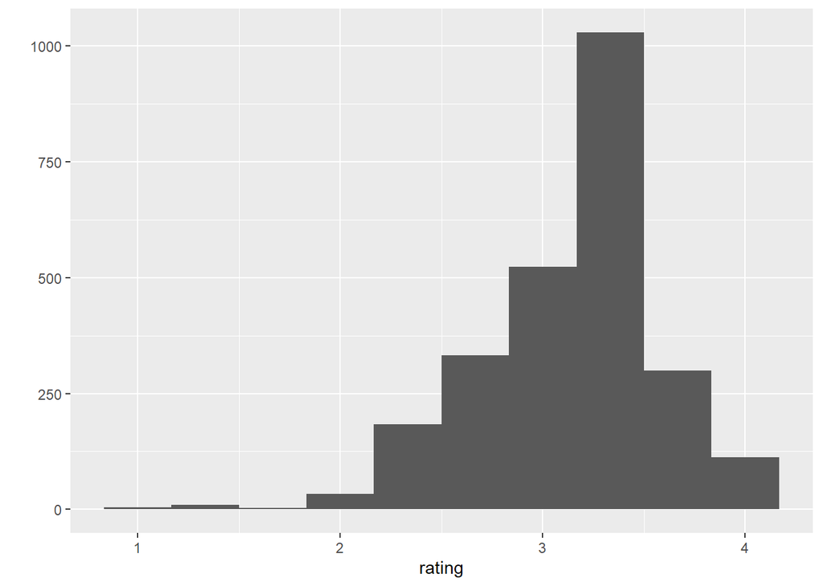

```r
qplot(rating, data=chocolate, bins = 10)
```

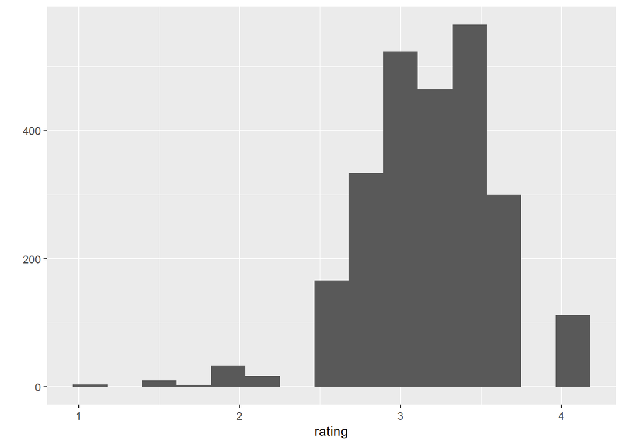

```r
qplot(rating, data=chocolate, bins = 15)
```

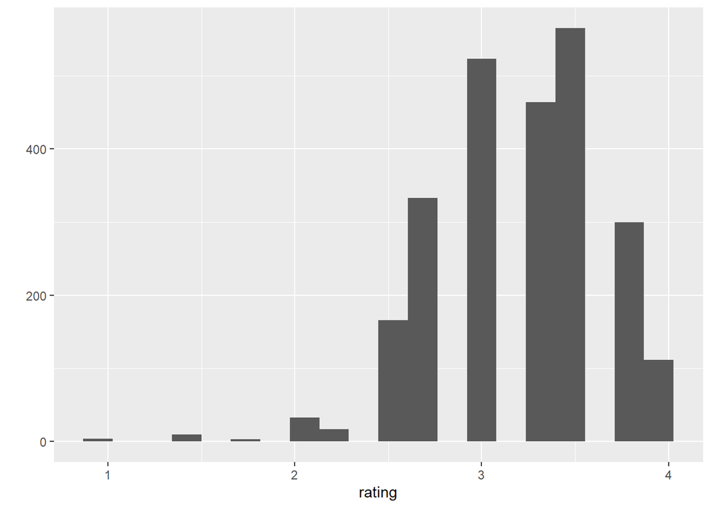

```r
qplot(rating, data=chocolate, bins = 20)
```

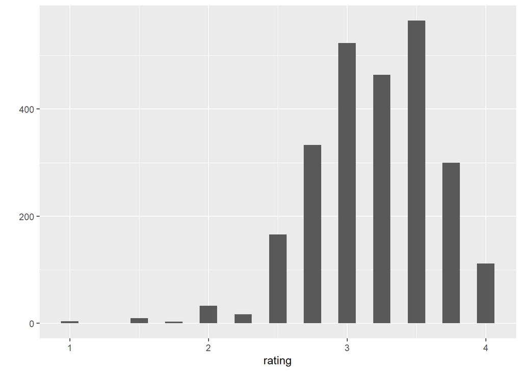

```r
qplot(rating, data=chocolate, bins = 25)
```

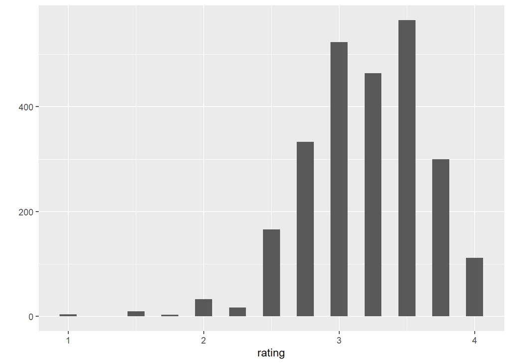

```r
#The one that looks the best
qplot(rating, data=chocolate, bins = 25)
```

Changing the bin number resulted in a separation the data into more categories. In essence, a higher bin number allowed for more categories of ratings, and subsequently, spread out the ratings in the histogram. I chose the graph with a bin number of 25 because it allowed me to see more of the data, since the bins themselves were smaller and there were more of them. I also liked the aesthetic look of the plot the best.

2. Consider the countries where the beans originated from. How many reviews come from each country of bean origin?

```r
chocolate %>%
  group_by(country_of_bean_origin) %>%
  count(chocolate$country_of_bean_origin)
```

```
## # A tibble: 62 × 3
## # Groups:   country_of_bean_origin [62]
##    country_of_bean_origin `chocolate$country_of_bean_origin`     n
##    <chr>                  <chr>                              <int>
##  1 Australia              Australia                              3
##  2 Belize                 Belize                                76
##  3 Blend                  Blend                                156
##  4 Bolivia                Bolivia                               80
##  5 Brazil                 Brazil                                78
##  6 Burma                  Burma                                  1
##  7 Cameroon               Cameroon                               3
##  8 China                  China                                  1
##  9 Colombia               Colombia                              79
## 10 Congo                  Congo                                 11
## # ℹ 52 more rows
```

3. What is average `rating` scores from reviews of chocolate bars that have Ecuador as `country_of_bean_origin` in this dataset? For this same set of reviews, also calculate (1) the total number of reviews and (2) the standard deviation of the `rating` scores. Your answer should be a new data frame with these three summary statistics in three columns. Label the name of these columns `mean`, `sd`, and `total`.

```r
chocolate.f <- filter(chocolate, country_of_bean_origin == "Ecuador")
chocolate.subset <- select(chocolate.f, rating)

chocolate.subset <- mutate(chocolate.subset, mean = mean(rating, na.rm=TRUE))
chocolate.subset <- mutate(chocolate.subset, total = count(chocolate.f))
chocolate.subset <- mutate(chocolate.subset, sd = sd(rating, na.rm = TRUE))
head(chocolate.subset)
```

```
## # A tibble: 6 × 4
##   rating  mean total$n    sd
##    <dbl> <dbl>   <int> <dbl>
## 1   3.75  3.16     219 0.512
## 2   2.75  3.16     219 0.512
## 3   3     3.16     219 0.512
## 4   3.5   3.16     219 0.512
## 5   2.75  3.16     219 0.512
## 6   4     3.16     219 0.512
```

4. Which company (name) makes the best chocolate (or has the highest ratings on average) with beans from Ecuador?

```r
company_avg_rating <-chocolate.f %>%
  group_by(company_manufacturer) %>%
  summarize(avg_rating = mean(rating, na.rm =TRUE))
head(company_avg_rating %>%
  arrange(desc(avg_rating)), 3)
```

```
## # A tibble: 3 × 2
##   company_manufacturer avg_rating
##   <chr>                     <dbl>
## 1 Amano                         4
## 2 Benoit Nihant                 4
## 3 Beschle (Felchlin)            4
```

5. Calculate the average rating across all country of origins for beans. Which top 3 countries (for bean origin) have the highest ratings on average?

```r
avg_rating <- mean(chocolate$rating, na.rm = TRUE)
print(avg_rating)
```

```
## [1] 3.196344
```

```r
country_avg_ratings1 <- chocolate %>%
  group_by(country_of_bean_origin) %>%
  summarize(avg_rating = mean(rating, na.rm = TRUE)) %>%
  arrange(desc(avg_rating))
head(select(country_avg_ratings1, avg_rating, country_of_bean_origin), 3)
```

```
## # A tibble: 3 × 2
##   avg_rating country_of_bean_origin
##        <dbl> <chr>
## 1       3.62 Tobago
## 2       3.5  China
## 3       3.5  Sao Tome & Principe
```

```r
str(chocolate)
```

```
## spc_tbl_ [2,530 × 10] (S3: spec_tbl_df/tbl_df/tbl/data.frame)
##  $ ref                             : num [1:2530] 2454 2458 2454 2542 2546 ...
##  $ company_manufacturer            : chr [1:2530] "5150" "5150" "5150" "5150" ...
##  $ company_location                : chr [1:2530] "U.S.A." "U.S.A." "U.S.A." "U.S.A." ...
##  $ review_date                     : num [1:2530] 2019 2019 2019 2021 2021 ...
##  $ country_of_bean_origin          : chr [1:2530] "Tanzania" "Dominican Republic" "Madagascar" "Fiji" ...
##  $ specific_bean_origin_or_bar_name: chr [1:2530] "Kokoa Kamili, batch 1" "Zorzal, batch 1" "Bejofo Estate, batch 1" "Matasawalevu, batch 1" ...
##  $ cocoa_percent                   : chr [1:2530] "76%" "76%" "76%" "68%" ...
##  $ ingredients                     : chr [1:2530] "3- B,S,C" "3- B,S,C" "3- B,S,C" "3- B,S,C" ...
##  $ most_memorable_characteristics  : chr [1:2530] "rich cocoa, fatty, bready" "cocoa, vegetal, savory" "cocoa, blackberry, full body" "chewy, off, rubbery" ...
##  $ rating                          : num [1:2530] 3.25 3.5 3.75 3 3 3.25 3.5 3.5 3.75 2.75 ...
##  - attr(*, "spec")=
##   .. cols(
##   ..   ref = col_double(),
##   ..   company_manufacturer = col_character(),
##   ..   company_location = col_character(),
##   ..   review_date = col_double(),
##   ..   country_of_bean_origin = col_character(),
##   ..   specific_bean_origin_or_bar_name = col_character(),
##   ..   cocoa_percent = col_character(),
##   ..   ingredients = col_character(),
##   ..   most_memorable_characteristics = col_character(),
##   ..   rating = col_double()
##   .. )
##  - attr(*, "problems")=<externalptr>
```

```r
chocolate_filtered  <- chocolate %>%
  group_by(country_of_bean_origin) %>%
  filter(n() >= 10)

country_avg_ratings2 <- chocolate_filtered %>%
  group_by(country_of_bean_origin) %>%
  summarize(avg_rating = mean(rating, na.rm = TRUE))

head(country_avg_ratings2 %>%
       arrange(desc(avg_rating)), 3)
```

```
## # A tibble: 3 × 2
##   country_of_bean_origin avg_rating
##   <chr>                       <dbl>
## 1 Solomon Islands              3.45
## 2 Congo                        3.32
## 3 Cuba                         3.29
```

7. For this last part, let's explore the relationship between percent chocolate and ratings.

   Use the functions in `dplyr`, `tidyr`, and `lubridate` to perform the following steps to the `chocolate` dataset:
   1. Identify the countries of bean origin with at least 50 reviews. Remove reviews from countries are not in this list.

```r
chocolate_f50  <- chocolate %>%
  group_by(country_of_bean_origin) %>%
  filter(n() >= 50)

countries_with_50ratings <- chocolate_f50 %>%
  pull(country_of_bean_origin) %>%
  unique()
```

2. Using the variable describing the chocolate percentage for each review, create a new column that groups chocolate percentages into one of four groups: (i) <60%, (ii) >=60 to <70%, (iii) >=70 to <90%, and (iii) >=90% (**Hint** check out the `substr()` function in base R and the `case_when()` function from `dplyr` – see example below).

```r
chocolate_f50 <- chocolate_f50 %>%
  mutate(chocolate_perc = case_when(
    substr(cocoa_percent, 1, 2) < 60 ~ "<60%",
    substr(cocoa_percent, 1, 2) >= 60 & substr(cocoa_percent, 1, 2) < 70 ~ ">=60% to <70%",
    substr(cocoa_percent, 1, 2) >= 70 & substr(cocoa_percent, 1, 2) < 90 ~ ">=70% to <90%",
    substr(cocoa_percent, 1, 2) >= 90 ~ ">=90%"
  ))

head(select(chocolate_f50, country_of_bean_origin, cocoa_percent, chocolate_perc))
```

```
## # A tibble: 6 × 3
## # Groups:   country_of_bean_origin [6]
##   country_of_bean_origin cocoa_percent chocolate_perc
##   <chr>                  <chr>         <chr>
## 1 Tanzania               76%           >=70% to <90%
## 2 Dominican Republic     76%           >=70% to <90%
## 3 Madagascar             76%           >=70% to <90%
## 4 Venezuela              72%           >=70% to <90%
## 5 Bolivia                70%           >=70% to <90%
## 6 Peru                   63%           >=60% to <70%
```

3. Using the new column described in #2, re-order the factor levels (if needed) to be starting with the smallest percentage group and increasing to the largest percentage group (**Hint** check out the `fct_relevel()` function from `forcats`).

```r
chocolate_f50 <- chocolate_f50 %>%
  mutate(chocolate_perc = fct_relevel(chocolate_perc,
                                      "<60%", ">=60% to <70%", ">=70% to <90%", ">=90%"
  ))
```

4. For each country, make a set of four side-by-side boxplots plotting the groups on the x-axis and the ratings on the y-axis. These plots should be faceted by country.

[figure not shown]

```r
g <- ggplot(chocolate_f50, aes(
  x= chocolate_perc,
  y= rating
))

g <- chocolate_f50 %>%
  ggplot(aes(chocolate_perc, rating))
print(g)
```

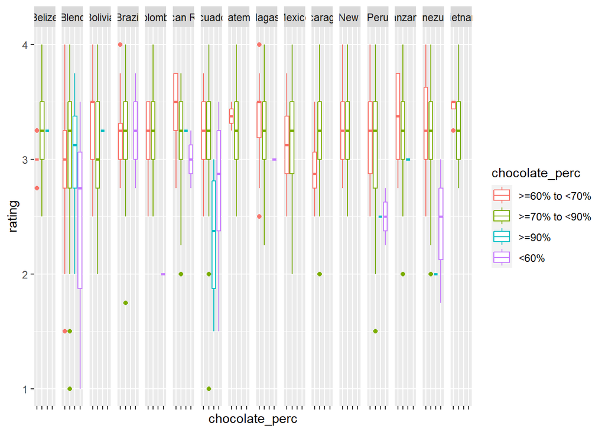

```r
g +
  geom_boxplot(aes(color = chocolate_perc)) +
  facet_grid(.~ country_of_bean_origin) +
  theme(axis.text.x=element_blank())
```

On average, which category of chocolate percentage is most highly rated? Do these countries mostly agree or are there disagreements?

On average, the >= 70% to <90% category is rated the highest across all countries with 50 or more ratings. However, not every country rated this category the highest. For example, Tanzania disagreed and rated the >= 60% to <70% category higher.

## Part 2: Join two datasets together

1. Use this dataset it to create a new column called `continent` in our `chocolate` dataset that contains the continent name for each review where the country of bean origin is.

```r
country_map <- gapminder %>%
  select(country, continent) %>%
  distinct()

chocolate_part2 <- chocolate %>%
  left_join(x = chocolate, y = country_map, by =c("country_of_bean_origin" ="country"))

chocolate_part2 <-chocolate_part2 %>%
  mutate(continent = case_when(
    (country_of_bean_origin == "Belize"|country_of_bean_origin == "Trinidad"|country_of_bean_origin == "St. Lucia") & is.na(continent) ~ "Americas",
    TRUE ~ continent
  )
  )

chocolate_part2 <-chocolate_part2 %>%
  mutate(continent = case_when(
    (country_of_bean_origin == "Congo"| country_of_bean_origin == "Sao Tome") & is.na(continent) ~ "Africa",
    TRUE ~ continent
  )
  )


chocolate_part2 <-chocolate_part2 %>%
  mutate(continent = case_when(
    (country_of_bean_origin == "Fiji"|country_of_bean_origin == "Papua New Guinea"| country_of_bean_origin == "Solomon Islands" |country_of_bean_origin == "Vanuatu")  & is.na(continent) ~ "Oceania",
    TRUE ~ continent
  )
  )



chocolate_part2 <-chocolate_part2 %>%
  mutate(continent = case_when(
    (country_of_bean_origin == "Grenada" | country_of_bean_origin == "U.S.A.") & is.na(continent) ~ "Americas",
    TRUE ~ continent
  )
  )

na_continent_rows <- subset(chocolate_part2, is.na(continent))
```

2. Only keep reviews that have reviews from countries of bean origin with at least 10 reviews.

```r
chocolate_part2 <- chocolate_part2 %>%
  group_by(country_of_bean_origin) %>%
  filter(n() >= 10)
```

3. Also, remove the country of bean origin named `"Blend"`.

```r
chocolate_part2 <- chocolate_part2 %>%
  filter(country_of_bean_origin != "Blend")
```

4. Make a set of violin plots with ratings on the y-axis and `continent`s on the x-axis.

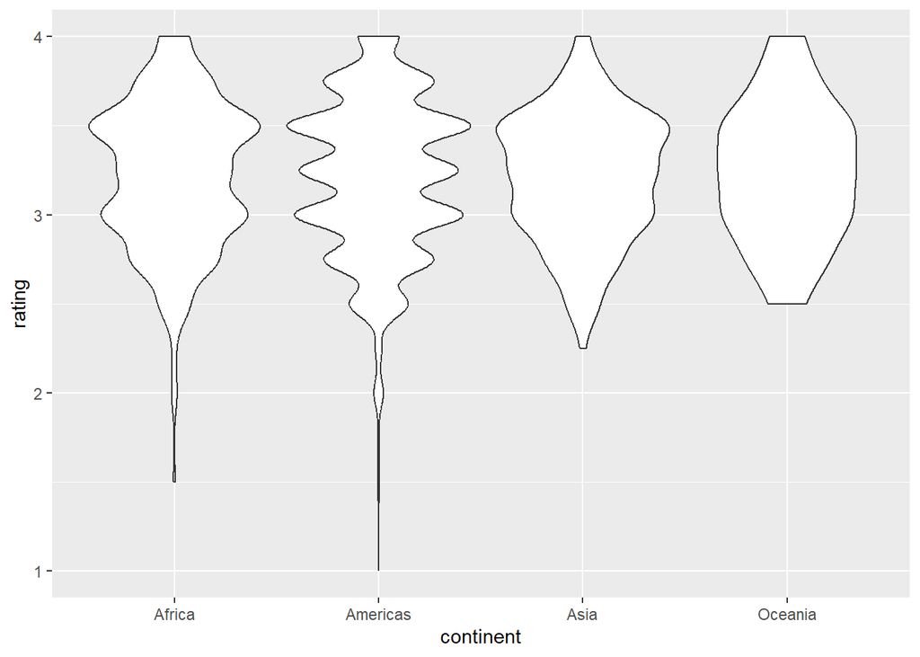

```r
g2 <- ggplot(chocolate_part2, aes(x = continent, y = rating))
g2 + geom_violin()
```